# The Olympics

**Week 2 Analysis**

## Background

We are given the data for all the Olympics, summer and winter, that took place between the years of 1898 and 2016. I want to find out if age is a factor in whether or not they can achieve a medal. If so does that also apply to both females and males, or does the outperforming age differ in the sex of the individual? I predict that younger males will produce more medals than younger females.

```r
# Code to get you started.
# Only the first 100 observations are shown here because the dataset is really too big to show all of it in a markdown file.
datatable(head(Olympics,100), options=list(lengthMenu = c(3,10,30)), extensions="Responsive")
```

|  | ID | Name | Sex | Age | Height | Weight | Team | NOC | Games | Year | Season | City | Sport | Event | Medal |
| --- | --- | --- | --- | --- | --- | --- | --- | --- | --- | --- | --- | --- | --- | --- | --- |
| 1 | 1 | A Dijiang | M | 24 | 180 | 80 | China | CHN | 1992 Summer | 1992 | Summer | Barcelona | Basketball | Basketball Men's Basketball |  |
| 2 | 2 | A Lamusi | M | 23 | 170 | 60 | China | CHN | 2012 Summer | 2012 | Summer | London | Judo | Judo Men's Extra-Lightweight |  |
| 3 | 3 | Gunnar Nielsen Aaby | M | 24 |  |  | Denmark | DEN | 1920 Summer | 1920 | Summer | Antwerpen | Football | Football Men's Football |  |
| 4 | 4 | Edgar Lindenau Aabye | M | 34 |  |  | Denmark/Sweden | DEN | 1900 Summer | 1900 | Summer | Paris | Tug-Of-War | Tug-Of-War Men's Tug-Of-War | Gold |
| 5 | 5 | Christine Jacoba Aaftink | F | 21 | 185 | 82 | Netherlands | NED | 1988 Winter | 1988 | Winter | Calgary | Speed Skating | Speed Skating Women's 500 metres |  |
| 6 | 5 | Christine Jacoba Aaftink | F | 21 | 185 | 82 | Netherlands | NED | 1988 Winter | 1988 | Winter | Calgary | Speed Skating | Speed Skating Women's 1,000 metres |  |
| 7 | 5 | Christine Jacoba Aaftink | F | 25 | 185 | 82 | Netherlands | NED | 1992 Winter | 1992 | Winter | Albertville | Speed Skating | Speed Skating Women's 500 metres |  |
| 8 | 5 | Christine Jacoba Aaftink | F | 25 | 185 | 82 | Netherlands | NED | 1992 Winter | 1992 | Winter | Albertville | Speed Skating | Speed Skating Women's 1,000 metres |  |
| 9 | 5 | Christine Jacoba Aaftink | F | 27 | 185 | 82 | Netherlands | NED | 1994 Winter | 1994 | Winter | Lillehammer | Speed Skating | Speed Skating Women's 500 metres |  |
| 10 | 5 | Christine Jacoba Aaftink | F | 27 | 185 | 82 | Netherlands | NED | 1994 Winter | 1994 | Winter | Lillehammer | Speed Skating | Speed Skating Women's 1,000 metres |  |

[output cut: 90 more lines]

## Analysis

First we have to look at only the individuals that achieved a medal, no matter if it was bronze or gold. For readability issues the data was divided into two groups initially, the Winter Olympics and the Summer Olympics.

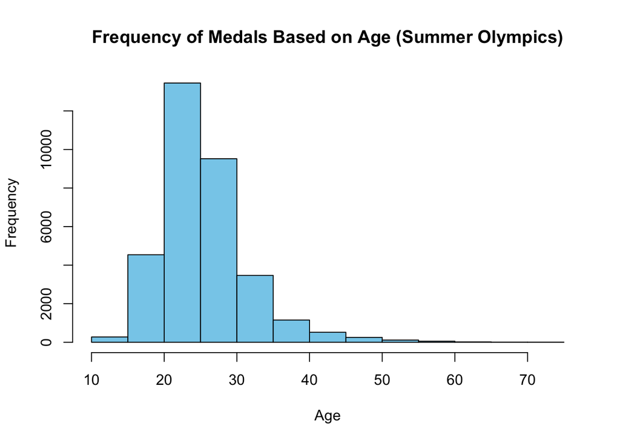

```r
hist(OlympicsSummerMedal$Age, col = "skyblue", xlab = "Age", main = "Frequency of Medals Based on Age (Summer Olympics)")
```

```r
outputTable <- rbind(Age=favstats(OlympicsSummerMedal$Age))
pander(outputTable[c("min","Q1","median","mean","Q3","max","n")], caption="Medals Based on Age for the Summer Olympics")
```

Medals Based on Age for the Summer Olympics

|  | min | Q1 | median | mean | Q3 | max | n |
| --- | --- | --- | --- | --- | --- | --- | --- |
| **Age** | 10 | 22 | 25 | 25.9 | 29 | 73 | 33367 |

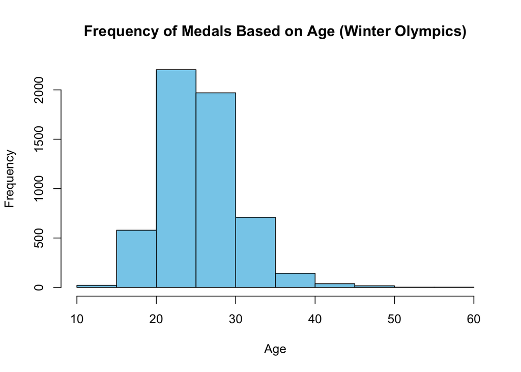

```r
hist(OlympicsWinterMedal$Age, col = "skyblue", xlab = "Age", main = "Frequency of Medals Based on Age (Winter Olympics)")
```

```r
outputTable <- rbind(Age=favstats(OlympicsWinterMedal$Age))
pander(outputTable[c("min","Q1","median","mean","Q3","max","n")], caption="Medals Based on Age for the Winter Olympics")
```

Medals Based on Age for the Winter Olympics

|  | min | Q1 | median | mean | Q3 | max | n |
| --- | --- | --- | --- | --- | --- | --- | --- |
| **Age** | 13 | 23 | 26 | 26.06 | 29 | 58 | 5684 |